# 08 Prepare : Homography

## Objectives

- Learning about feature detection and homography in OpenCV
- A great source of examples of using OpenCV in Python is [found here](https://opencv-python-tutroals.readthedocs.io/en/latest/py_tutorials/py_tutorials.html)

## Topic

We introduced feature detection in last week's lesson. We will extend this topic to the area called homography

## Reading Material

You will be watching the following [VIDEO - Watch Me](https://www.youtube.com/watch?v=cA8K8dl-E6k) that describes using feature detection and homography. I've included the completed program here.

Before watching this video, we are going over a few topic/functions:

### Homography Definition

> a type of transformation that maps straight lines onto another plane

When you have the same object in two images where they are warped or rotated, you can use feature detection to find matching points between them. If we have enough points and we know that the camera is in the same location for both images (There will always be a little difference), we can create a warping matrix that will convert one iamge to the other to match it's plane/perspective.

### 1) warpAffine() and warpPerspective()

[affine transformations](https://brilliant.org/wiki/affine-transformations/)

[OpenCV Documention](https://opencv-python-tutroals.readthedocs.io/en/latest/py_tutorials/py_imgproc/py_geometric_transformations/py_geometric_transformations.html)

> OpenCV provides two transformation functions, cv2.warpAffine and cv2.warpPerspective, with which you can have all kinds of transformations. cv2.warpAffine takes a 2x3 transformation matrix while cv2.warpPerspective takes a 3x3 transformation matrix as input.

When we find a transform matrix (Homography matrix) between two planes, we can use warpPerspective() to "warp" one image to the other plane.

### 2) findHomography()

[image alignment](https://learnopencv.com/image-alignment-feature-based-using-opencv-c-python/)

This function takes in a list of matching feature points from two images and returns the transform matrix between the planes of the images.

## Code sample from reading material video

Here are the following images used in the code sample. Note, that the two images don't need to be exact, they just need to contain the same object in both images. For your assignment, you will be processing frames in a video where the object of the video are in both frames, they will be a little different.

### monkey.jpg

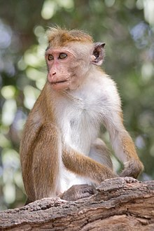

### monkey_distorted.jpg

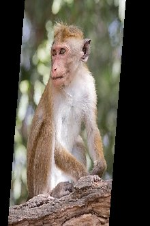

```
"""
Code from:
https://github.com/bnsreenu/python_for_microscopists/blob/master/030-keypoints_homography_for_registration%20in%20opencv.py
"""

__author__ = "Sreenivas Bhattiprolu"
__license__ = "Feel free to copy, I appreciate if you acknowledge Python for Microscopists"

# https://www.youtube.com/watch?v=cA8K8dl-E6k

# Brute-Force Matching with ORB Descriptors

import numpy as np
import cv2
from matplotlib import pyplot as plt

im1 = cv2.imread('monkey_distorted.jpg')          # Image that needs to be registered.
im2 = cv2.imread('monkey.jpg') # trainImage

img1 = cv2.cvtColor(im1, cv2.COLOR_BGR2GRAY)
img2 = cv2.cvtColor(im2, cv2.COLOR_BGR2GRAY)

# Initiate ORB detector
orb = cv2.ORB_create(50)  #Registration works with at least 50 points

# find the keypoints and descriptors with orb
kp1, des1 = orb.detectAndCompute(img1, None)  #kp1 --> list of keypoints
kp2, des2 = orb.detectAndCompute(img2, None)

#Brute-Force matcher takes the descriptor of one feature in first set and is
#matched with all other features in second set using some distance calculation.
# create Matcher object

matcher = cv2.DescriptorMatcher_create(cv2.DESCRIPTOR_MATCHER_BRUTEFORCE_HAMMING)

# Match descriptors.
matches = matcher.match(des1, des2, None)  #Creates a list of all matches, just like keypoints

# Sort them in the order of their distance.
matches = sorted(matches, key = lambda x:x.distance)

#Like we used cv2.drawKeypoints() to draw keypoints,
#cv2.drawMatches() helps us to draw the matches.
#https://docs.opencv.org/3.0-beta/modules/features2d/doc/drawing_function_of_keypoints_and_matches.html
# Draw first 10 matches.
img3 = cv2.drawMatches(im1,kp1, im2, kp2, matches[:10], None)

cv2.imshow("Matches image", img3)
# cv2.waitKey(0)

#Now let us use these key points to register two images.
#Can be used for distortion correction or alignment
#For this task we will use homography.
# https://docs.opencv.org/3.4.1/d9/dab/tutorial_homography.html

# Extract location of good matches.
# For this we will use RANSAC.
#RANSAC is abbreviation of RANdom SAmple Consensus,
#in summary it can be considered as outlier rejection method for keypoints.
#http://eric-yuan.me/ransac/
#RANSAC needs all key points indexed, first set indexed to queryIdx
#Second set to #trainIdx.

points1 = np.zeros((len(matches), 2), dtype=np.float32)  #Prints empty array of size equal to (matches, 2)
points2 = np.zeros((len(matches), 2), dtype=np.float32)

for i, match in enumerate(matches):
   points1[i, :] = kp1[match.queryIdx].pt    #gives index of the descriptor in the list of query descriptors
   points2[i, :] = kp2[match.trainIdx].pt    #gives index of the descriptor in the list of train descriptors

#Now we have all good keypoints so we are ready for homography.
# Find homography
#https://en.wikipedia.org/wiki/Homography_(computer_vision)

h, mask = cv2.findHomography(points1, points2, cv2.RANSAC)

# Use homography
height, width, channels = im2.shape
im1Reg = cv2.warpPerspective(im1, h, (width, height))  #Applies a perspective transformation to an image.

print("Estimated homography : \n",  h)

cv2.imshow("Registered image", im1Reg)
cv2.waitKey()
```

## Links

- [What is Homography](https://en.wikipedia.org/wiki/Homography)
- [Video on video stablization](https://www.youtube.com/watch?v=BgAdeuxkUyY&feature=emb_rel_pause)
- [Basic concepts of the homography explained with code](https://docs.opencv.org/master/d9/dab/tutorial_homography.html)
- [Video on object tracking](https://www.youtube.com/watch?v=I8tHLZDDHr4)